# RNA-seq application

Siyu Lin (2501111616@stu.pku.edu.cn), Zexian Zeng(zexianzeng@pku.edu.cn)

Center for Quantitative Biology

Academy for Advanced Interdisciplinary Studies, Peking University

Lab website: http://cqb.pku.edu.cn/zenglab/

## Part 0. Preparations of coding

1. log in your account on the server by

   `ssh -i {Path_to_your_private_key_file} -p 16122 {Your_username}@162.105.160.16`
2. Set up your environment variables
   - Make sure you are at your root directory after logging in via `pwd`
   - Make a new file namely ".bashrc" via `touch .bashrc`
   - Writing the path of conda into your environment variable file by `vim .bashrc` and copy the following contents into it:

     ```bash
     # .bashrc

     # Source global definitions
     if [ -f /etc/bashrc ]; then
      . /etc/bashrc
     fi

     # User specific environment
     if ! [[ "$PATH" =~ "$HOME/.local/bin:$HOME/bin:" ]]
     then
      PATH="$HOME/.local/bin:$HOME/bin:$PATH"
     fi
     export PATH

     # Uncomment the following line if you don't like systemctl's auto-paging feature:
     # export SYSTEMD_PAGER=

     # User specific aliases and functions

     # >>> conda initialize >>>
     # !! Contents within this block are managed by 'conda init' !!
     __conda_setup="$('/lustre1/share/miniconda3/bin/conda' 'shell.bash' 'hook' 2> /dev/null)"
     if [ $? -eq 0 ]; then
      eval "$__conda_setup"
     else
      if [ -f "/lustre1/share/miniconda3/etc/profile.d/conda.sh" ]; then
          . "/lustre1/share/miniconda3/etc/profile.d/conda.sh"
      else
          export PATH="/lustre1/share/miniconda3/bin:$PATH"
      fi
     fi
     unset __conda_setup
     # <<< conda initialize <<<
     ```

   - Type `:` and then `wq!`. This will save the changes of .bashrc file.
   - Finally, use `source .bashrc` to activate your environment variables.
   - Simply type `conda` and you'll see the usage of conda. It works!!!
3. Enter the virtual environment by typing `conda activate rnaimmune` All the packages used in this class have been installed as follows.

   *Note: **You don't need to** run the codes in this section, unless you want to build your own environment.*

   ```bash
   mamba install -c bioconda -c conda-forge r-immunedeconv r-tidyverse r-pheatmap r-hmisc r-survminer r-proc
   pip install tidepy
   ```

   In order to run xCell successfully, matrixStats 1.1.0 is required. It can be downloaded from https://github.com/cran/matrixStats/releases, and it has been installed **in R**.

   ```r
   install.packages("/path_to_your_folder/matrixStats-1.1.0.tar.gz", repos=NULL) # for xCell
   ```

   *Note: in this handbook, there are some `path_to_your_folder` in the code. Replace them with the path (pay attention to the difference between the absolute path and the relative path) where you store files or where you want to save results.*

   Due to licensing restrictions, CIBERSORT is not included in the immunedeconv package. In order to use CIBERSORT through immunedeconv's unified interface, we need to download the source code from the authors' website https://cibersort.stanford.edu/. The source code package contains two files `CIBERSORT.R` and `LM22.txt` that are required for running CIBERSORT through immunedeconv. These two files are stored at `/lustre1/share/rnaimmune`.

### **Data**

The RNA-seq data that we will use in this class can be found at `/lustre1/share/rnaimmune/data`

In this folder, there are two subfolders, `expression` and `follow_up`. The Matrix in `expression` is a count matrix, with rows as genes and columns as samples. The Matrix in `follow_up` records metadata of samples.

The RNA-seq data was generated by [(Van Allen et al., 2015)](https://www.science.org/doi/10.1126/science.aad0095). It contains whole-transcriptome sequencing of tumor biopsies of 42 patients with metastatic melanoma before ipilimumab (anti-CTLA-4) treatment.

### **output**

Before we start, `cd` into your own home, and create a folder for the outputs of this class.

```bash
cd
mkdir rnaimmune_output
cd rnaimmune_output
```

## Part 1. Gene correlation analysis

### **A. Load and normalize RNA-seq Data**

Firstly, let's open **R**.

```bash
R
```

*Note: The working directory is the folder where you run R. Any relative path is relative to the working directory. You can change it with the function `setwd`.*

We load the RNA-seq data into R, and take a galce at it.

*Note: Except for special instructions, all the following codes are run **in R**.*

```r
exprsn <- read.table('/lustre1/share/rnaimmune/data/expression/VanAllen2015_CTLA4_Melanoma_RNASeq', sep='\t', header=TRUE, row.names=1)
print(exprsn[1:5,1:5])
print(head(colSums(exprsn)))
```

The expression matrix has not been normalized. Let's normalized it to CPM.

```r
exprsn <- t(t(exprsn)/colSums(exprsn)*1e6)
print(head(colSums(exprsn)))
```

### **B. Gene-to-gene correlation**

We analyze the correlation between two specific genes: *GZMA* (Granzyme A) and *PRF1* (Perforin 1). These two genes indicate immune cytolytic activity (CYT).

```r
library(Hmisc)
library(ggplot2)

gene1 <- 'GZMA'
gene2 <- 'PRF1'

pearson_corr <- rcorr(exprsn[gene1,], exprsn[gene2,], type = 'pearson')
spearman_corr <- rcorr(exprsn[gene1,], exprsn[gene2,], type = 'spearman')

print(spearman_corr)
```

- **Pearson correlation** measures the linear relationship between two genes.
- **Spearman correlation** captures monotonic relationships, accounting for ranks instead of actual values.

We plot the expression levels of the two genes to visualize their correlation.

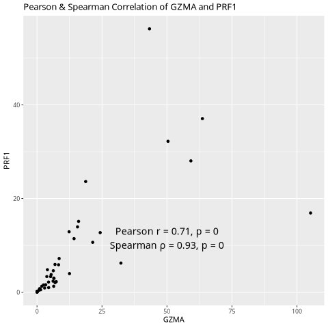

```r
df <- data.frame(t(rbind(exprsn[gene1,], exprsn[gene2,])))
colnames(df) <- c('gene1', 'gene2')

pearson_label <- paste0('Pearson r = ', round(pearson_corr$r[1,2], 2), ', p = ', round(pearson_corr$P[1,2], 4))
spearman_label <- paste0('Spearman ρ = ', round(spearman_corr$r[1,2], 2), ', p = ', round(spearman_corr$P[1,2], 4))

# scatter plot
p <- ggplot(df, aes(gene1, gene2))
p <- p + geom_point()
p <- p + annotate("text", x = 50, y = 13, label = pearson_label, size = 5)
p <- p + annotate("text", x = 50, y = 10, label = spearman_label, size = 5)
p <- p + xlab(gene1)
p <- p + ylab(gene2)
p <- p + ggtitle(paste("Pearson & Spearman Correlation of", gene1, 'and', gene2))
png('GZMA_cor_PRF1.png')
print(p)
dev.off()
```

This scatter plot displays gene expression levels, annotated with Pearson and Spearman correlation values.

### **C. Gene-to-signature correlation**

Next, we explore the correlation between a **gene set** (*GZMA* & *PRF1*) and a single gene, *CTLA4*. Here, we compute the **mean expression** of *GZMA* & *PRF1* as the signature **CYT**.

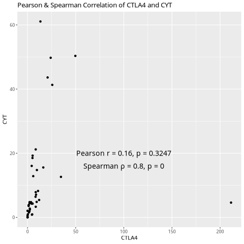

```r
geneset <- c('GZMA', 'PRF1')
sig <- colMeans(exprsn[geneset,])
sig_name <- 'CYT'
gene <- 'CTLA4'

pearson_corr <- rcorr(sig, exprsn[gene,], type = 'pearson')
spearman_corr <- rcorr(sig, exprsn[gene,], type = 'spearman')

df <- data.frame(t(rbind(sig, exprsn[gene,])))
colnames(df) <- c('sig', 'gene')

pearson_label <- paste0('Pearson r = ', round(pearson_corr$r[1,2], 2), ', p = ', round(pearson_corr$P[1,2], 4))
spearman_label <- paste0('Spearman ρ = ', round(spearman_corr$r[1,2], 2), ', p = ', round(spearman_corr$P[1,2], 4))

# scatter plot
p <- ggplot(df, aes(gene, sig))
p <- p + geom_point()
p <- p + annotate("text", x = 100, y = 20, label = pearson_label, size = 5)
p <- p + annotate("text", x = 100, y = 16, label = spearman_label, size = 5)
p <- p + xlab(gene)
p <- p + ylab(sig_name)
p <- p + ggtitle(paste("Pearson & Spearman Correlation of", gene, 'and', sig_name))
png('CTLA4_cor_CYT.png')
print(p)
dev.off()
```

## Part 2. Survival analysis

### **A. Load metadata**

We assess the relationship between gene expression and patient survival data. First, we load the survival data and reorder it to be consistent with the expression matrix.

```r
library(survival)
library(survminer)
library(dplyr)

metadata <- read.table('/lustre1/share/rnaimmune/data/follow_up/VanAllen2015_CTLA4_Melanoma_RNASeq', sep='\t', header=TRUE, row.names=1)
metadata <- metadata[colnames(exprsn),] # reorder to be consistent with exprsn
head(metadata)
```

- In the columns 'OS.Event' and 'PFS.Event', 0 = no event (censored), 1 = event (death or tumor progression).
- In the column 'Gender', 0 = female, 1 = male.
- In the column 'Response', 0 = Non-responder, 1 = Responder.

Now, we have prepared everything that will be used in our class.

### **B. Kaplan-Meier Survival Plot**

We divide patients into two groups based on their **CYT** levels (high and low):

```r
metadata$CYT <- sig
metadata <- metadata %>% mutate(CYT_level = ifelse(CYT > median(CYT), "high", "low"))
head(metadata)
```

We use the Kaplan-Meier estimator to visualize survival differences between the two groups.

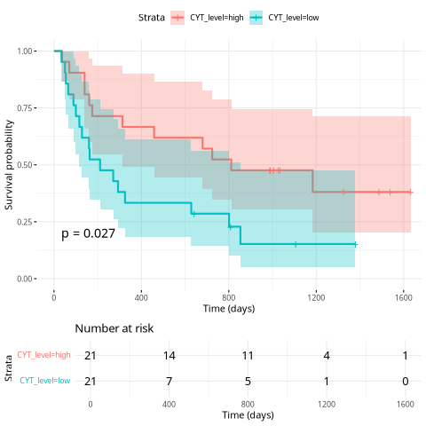

```r
surv_obj <- Surv(time = metadata$OS, event = metadata$`OS.Event`)
fit <- survfit(surv_obj ~ CYT_level, data = metadata)

# K-M plot
p <- ggsurvplot(fit, data = metadata,
                pval = TRUE,
                conf.int = TRUE,
                risk.table = TRUE,
                ggtheme = theme_minimal())
p <- p + xlab('Time (days)')
png('survival_CYT.png')
print(p)
dev.off()
```

### **C. Cox proportional hazards model**

Finally, we use the Cox proportional hazards model to evaluate the effect of multiple variables on survival, including age, gender, cancer stage, **CYT** level, and *CTLA4* expression level. This model provides hazard ratios (HR) for each variable, indicating their influence on overall survival.

The Cox model:

$$h(t)=h0(t)×exp(b1x1+b2x2+⋯+bpxp)$$

The harzard ratio of $xi$ is then $exp(bi)$

```r
metadata$CTLA4 <- exprsn['CTLA4',]
metadata$Gender <- factor(metadata$Gender, levels=c(0,1))
levels(metadata$Gender) <- c('Female', 'Male')
cox_model <- coxph(Surv(OS, `OS.Event`) ~ Age + Gender + Stage + CYT + CYT_level + CTLA4, data = metadata)
```

*Note: In R, the `~` symbol is used to specify a **formula**, which is commonly used in statistical modeling and plotting functions.*

Have a look at the regression results with `summary`.

```r
summary(cox_model)
```

The forest plot visually summarizes these results.

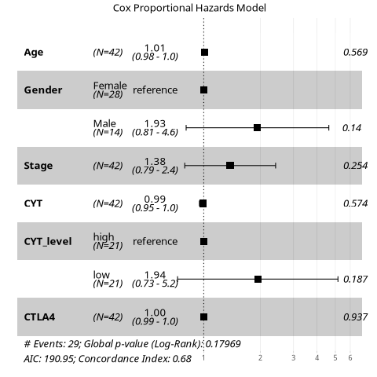

```r
# forest plot
png('cox.png')
ggforest(cox_model, data = metadata,
         main = "Cox Proportional Hazards Model",
         fontsize = 1.2)
dev.off()
```

## Part 3. Immune infiltration analysis

### **A. Deconvolute immune cell fractions**

```r
library(tidyverse)
library(pheatmap)
library(immunedeconv)
set_cibersort_binary("/lustre1/share/rnaimmune/CIBERSORT.R")
set_cibersort_mat("/lustre1/share/rnaimmune/LM22.txt")
```

To estimate immune cell fractions, we have to invoke the `deconvolute` function. It requires the specification of one of the following methods for deconvolution:

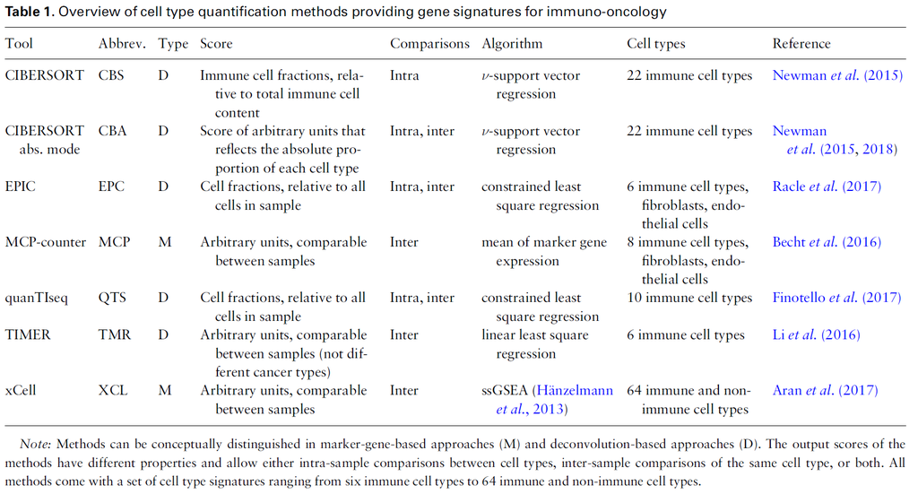

```r
print(deconvolution_methods)
```

The `deconvolute` function produces a data.frame with the first column containing the cell-type names and the other columns containing the estimates for each sample.

```r
# MCP-counter
res_mcp <- deconvolute(exprsn, "mcp_counter")
# EPIC
res_epc <- deconvolute(exprsn, "epic")
# quanTIseq
res_qts <- deconvolute(exprsn, "quantiseq")
# xCell
res_xcl <- deconvolute(exprsn, "xcell")
# CIBERSORT
res_cbs <- deconvolute(exprsn, "cibersort") # will save results in the work dir
# CIBERSORT abs. mode
res_cba <- deconvolute(exprsn, "cibersort_abs")
# TIMER
res_tmr <- deconvolute(exprsn, "timer", indications = rep('skcm', ncol(exprsn)))
```

Excluding genes with low cell-type specificity can reduce spillover-effects and improve overall results. If you find a gene to impair the results, you can exclude it using the `rmgenes` parameter. Here we remove six genes that are expressed by both B cells and plasmacytoid dendritic cells (pDCs).

```r
res_qts <- deconvolute(
    exprsn, method='quantiseq',
    rmgenes = c('TCL1A', 'TCF4', 'CD37', 'SPIB', 'IRF8', 'BCL11A'))
```

To be able to run TIMER, you have to provide the proper tumor-type to the `deconvolute` function. The full list of abbreviations is available on the [TCGA wiki](https://gdc.cancer.gov/resources-tcga-users/tcga-code-tables/tcga-study-abbreviations) and stored in `timer_available_cancers`.

```r
print(timer_available_cancers)
```

Have a glance at the results. Each contains a `tibble` with the first column as cell types.

```r
print(res_qts)
```